# SPPH 504 Section 007 Lab 6: Machine learning and Application in Propensity Score Analysis

Ehsan Karim, ehsan.karim@ubc.ca

01 May 2020

# 1 Data

```r
load("data/NHANES15to16chl.RData")
ls()
```

```
## [1] "analytic3"    "formula.bin"  "formula.cont"
```

```r
formula.cont
```

```
## cholesterol ~ gender + age + born + race + education + married +
##     income + diastolicBP + systolicBP + bmi + triglycerides +
##     uric.acid + protein + bilirubin + phosphorus + sodium + potassium +
##     globulin + calcium + physical.work + physical.recreational +
##     diabetes
```

```r
formula.bin
```

```
## cholesterol.bin ~ gender + age + born + race + education + married +
##     income + diastolicBP + systolicBP + bmi + triglycerides +
##     uric.acid + protein + bilirubin + phosphorus + sodium + potassium +
##     globulin + calcium + physical.work + physical.recreational +
##     diabetes
```

```r
str(analytic3)
```

```
## 'data.frame':    2632 obs. of  36 variables:
##  $ ID                   : num  83732 83733 83735 83736 83741 ...
##  $ gender               : chr  "Male" "Male" "Female" "Female" ...
##  $ age                  : num  62 53 56 42 22 32 46 45 30 67 ...
##  $ born                 : chr  "Born in 50 US states or Washingt" "Others" "Born in 50 US states or Washingt" "Born in 50 US states or Washingt" ...
##  $ race                 : chr  "White" "White" "White" "Black" ...
##  $ education            : chr  "College" "High.School" "College" "College" ...
##  $ married              : chr  "Married" "Previously.married" "Married" "Previously.married" ...
##  $ income               : chr  "Between.55kto99k" "<25k" "Between.55kto99k" "Between.25kto54k" ...
##  $ weight               : num  135630 25282 102079 18235 39353 ...
##  $ psu                  : num  1 1 1 2 2 1 1 1 1 1 ...
##  $ strata               : num  125 125 131 126 128 125 121 125 124 128 ...
##  $ diastolicBP          : num  70 88 72 70 70 70 94 70 50 76 ...
##  $ systolicBP           : num  128 146 132 100 110 120 144 116 104 124 ...
##  $ bodyweight           : num  94.8 90.4 109.8 55.2 76.6 ...
```

[output cut: 22 more lines]

# 2 Paramters of interest in Prediction modelling

Ref: Chapter 8: (Kuhn and Johnson 2013)

- Regression
  - Fitted by minimizing Residual Sum of square (RSS)
  - RSS = $\sum_{i=1}^n (Y_i - \hat{Y}_i)$
  - RSS = $\sum_{i=1}^n (Y_i - \beta_0 + \sum_{j=1}^p \beta_j X_{ij})$
  - No shrinkage / penalty
- Ridge
  - RSS + $\lambda \sum_{j=1}^p \beta_j^2$
  - RSS + $\lambda L_2$, where $L_2$ = $\sum_{j=1}^p \beta_j^2$
  - Here, $\lambda$ = regularization/tuning parameter
  - $\lambda$ controls the overall strength of the penalty.
  - Ridge penalty shrinks the coefficients of correlated predictors towards each (can’t be 0)
- LASSO
  - RSS + $\lambda \sum_{j=1}^p |\beta_j|$
  - RSS + $\lambda L_1$, where $L_1 = \sum_{j=1}^p |\beta_j|$
  - LASSO penalty tends to pick one of the correlated predictors and discard the others (assigns 0)
- Elastic net (combination of Ridge and LASSO)
  - RSS + $(1-\alpha) \lambda L_2 + \alpha \lambda L_1$
  - RSS + $\lambda [ (1-\alpha) L_2 + \alpha L_1 ]$
  - Here, $\alpha$ = The mixing parameter
    - $\alpha$ = 1 is the lasso penalty, and
    - $\alpha$ = 0 the ridge penalty.
    - $\alpha$ = between 0 and 1 (e.g., 0.2);
      - the elasticnet/mixing penalty.

# 3 No Shrinkage

```r
formula.cont
```

```
## cholesterol ~ gender + age + born + race + education + married +
##     income + diastolicBP + systolicBP + bmi + triglycerides +
##     uric.acid + protein + bilirubin + phosphorus + sodium + potassium +
##     globulin + calcium + physical.work + physical.recreational +
##     diabetes
```

```r
ctrl<-trainControl(method = "cv",number = 10)

lmfit <- train(formula.cont, method = "lm",
                  data = analytic3,
                  trControl = ctrl)
lmfit
```

```
## Linear Regression
##
## 2632 samples
##   22 predictor
##
## No pre-processing
## Resampling: Cross-Validated (10 fold)
## Summary of sample sizes: 2368, 2370, 2368, 2370, 2369, 2369, ...
## Resampling results:
##
##   RMSE      Rsquared   MAE
##   35.46458  0.2241368  27.73247
##
## Tuning parameter 'intercept' was held constant at a value of TRUE
```

```r
require(MASS)
ctrl<-trainControl(method = "cv",number = 10)
lmstepfit <- train(formula.cont, method = "lmStepAIC",
                   direction = "backward",
                   trace = 0,
                   data = analytic3,
                   trControl = ctrl)
lmstepfit
```

```
## Linear Regression with Stepwise Selection
##
## 2632 samples
##   22 predictor
##
## No pre-processing
## Resampling: Cross-Validated (10 fold)
## Summary of sample sizes: 2371, 2369, 2367, 2370, 2370, 2368, ...
## Resampling results:
##
##   RMSE      Rsquared   MAE
##   35.39953  0.2263696  27.68812
```

```r
lmstepfit$finalModel
```

```
##
## Call:
## lm(formula = .outcome ~ genderMale + age + bornOthers + raceHispanic +
##     raceOther + educationHigh.School + marriedNever.married +
##     incomeBetween.55kto99k + incomeOver100k + diastolicBP + bmi +
##     triglycerides + uric.acid + protein + bilirubin + sodium +
##     calcium + diabetesYes, data = dat)
##
## Coefficients:
##            (Intercept)              genderMale                     age
##               135.9919                -12.7534                  0.3546
##             bornOthers            raceHispanic               raceOther
##                 7.7047                 -5.6093                 -4.3238
##   educationHigh.School    marriedNever.married  incomeBetween.55kto99k
##                 3.1114                 -5.4693                  3.2385
##         incomeOver100k             diastolicBP                     bmi
##                 3.5434                  0.3898                 -0.3290
##          triglycerides               uric.acid                 protein
##                 0.1244                  1.3650                  3.1689
##              bilirubin                  sodium                 calcium
##                -5.8957                 -1.0043                 13.0665
##            diabetesYes
##               -18.9716
```

```r
length(lmstepfit$finalModel)
```

[output not shown]

```r
# original model had 22 predictors
```

# 4 Shrinkage approaches for continuous outcome

## 4.1 Given $\alpha$, $\lambda$

```r
require(glmnet)
TuneGrid <- expand.grid(alpha = 1,
                        lambda = .1)
ctrl<-trainControl(method = "cv",number = 10)

lassofit <- train(formula.cont, method = "glmnet",
                  data = analytic3,
                  trControl = ctrl,
                  tuneGrid = TuneGrid)
lassofit
```

```
## glmnet
##
## 2632 samples
##   22 predictor
##
## No pre-processing
## Resampling: Cross-Validated (10 fold)
## Summary of sample sizes: 2369, 2368, 2369, 2369, 2368, 2368, ...
## Resampling results:
##
##   RMSE      Rsquared  MAE
##   35.35868  0.23102   27.65944
##
## Tuning parameter 'alpha' was held constant at a value of 1
##
## Tuning parameter 'lambda' was held constant at a value of 0.1
```

```r
# Note that alpha, lambda values were provided (no optimization)
```

## 4.2 Given $\alpha$, optimize $\lambda$

### 4.2.1 Preliminary analysis

```r
TuneGrid <- expand.grid(alpha = 1,
                        lambda = seq(0,1,by = 0.1))
ctrl<-trainControl(method = "cv",number = 5)

lassofit2 <- train(formula.cont, method = "glmnet",
                  data = analytic3,
                  trControl = ctrl,
                  tuneGrid = TuneGrid)
lassofit2
```

```
## glmnet
##
## 2632 samples
##   22 predictor
##
## No pre-processing
## Resampling: Cross-Validated (5 fold)
## Summary of sample sizes: 2105, 2105, 2106, 2106, 2106
## Resampling results across tuning parameters:
##
##   lambda  RMSE      Rsquared   MAE
##   0.0     35.37722  0.2276817  27.68307
##   0.1     35.35407  0.2284902  27.66962
##   0.2     35.33847  0.2291023  27.65718
##   0.3     35.33916  0.2291527  27.65786
##   0.4     35.35392  0.2286958  27.67014
##   0.5     35.37108  0.2282191  27.68484
##   0.6     35.39280  0.2276162  27.70267
##   0.7     35.41730  0.2269742  27.72329
##   0.8     35.44380  0.2262968  27.74784
##   0.9     35.47413  0.2254750  27.77401
##   1.0     35.50845  0.2245055  27.80135
##
## Tuning parameter 'alpha' was held constant at a value of 1
## RMSE was used to select the optimal model using the smallest value.
## The final values used for the model were alpha = 1 and lambda = 0.2.
```

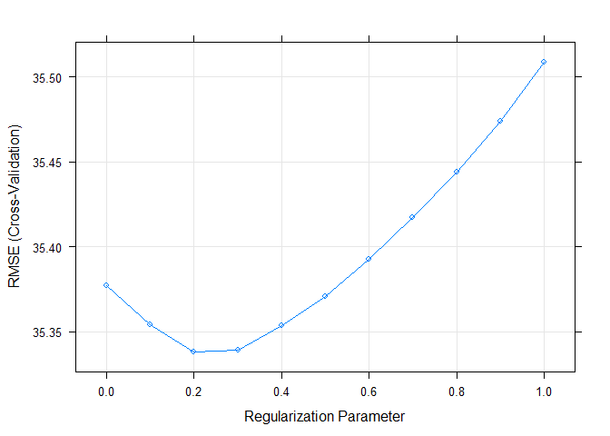

```r
plot(lassofit2)
```

```r
lassofit2$bestTune
```

```
##   alpha lambda
## 3     1    0.2
```

### 4.2.2 Fine tuning

```r
TuneGrid <- expand.grid(alpha = 1,
                        lambda = seq(0.2,.3,by = 0.01))
ctrl<-trainControl(method = "cv",number = 5)

lassofit3 <- train(formula.cont, method = "glmnet",
                  data = analytic3,
                  trControl = ctrl,
                  tuneGrid = TuneGrid)
lassofit3
```

```
## glmnet
##
## 2632 samples
##   22 predictor
##
## No pre-processing
## Resampling: Cross-Validated (5 fold)
## Summary of sample sizes: 2105, 2107, 2105, 2105, 2106
## Resampling results across tuning parameters:
##
##   lambda  RMSE      Rsquared   MAE
##   0.20    35.43956  0.2275698  27.66809
##   0.21    35.44014  0.2275592  27.66926
##   0.22    35.44077  0.2275474  27.67048
##   0.23    35.44160  0.2275282  27.67180
##   0.24    35.44261  0.2275013  27.67314
##   0.25    35.44373  0.2274712  27.67447
##   0.26    35.44497  0.2274373  27.67574
##   0.27    35.44620  0.2274049  27.67690
##   0.28    35.44760  0.2273663  27.67811
##   0.29    35.44904  0.2273265  27.67930
##   0.30    35.45054  0.2272855  27.68052
##
## Tuning parameter 'alpha' was held constant at a value of 1
## RMSE was used to select the optimal model using the smallest value.
## The final values used for the model were alpha = 1 and lambda = 0.2.
```

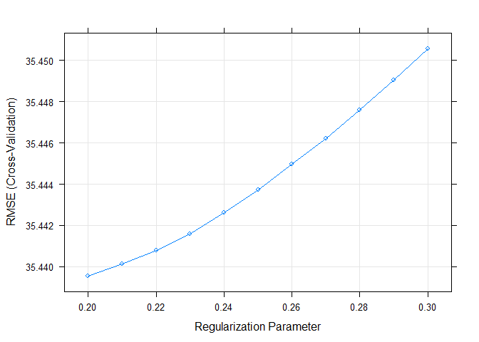

```r
plot(lassofit3)
```

```r
lassofit3$bestTune
```

```
##   alpha lambda
## 1     1    0.2
```

## 4.3 Optimize $\alpha$ and $\lambda$

```r
TuneGrid <- expand.grid(alpha = seq(0,1,.5),
                        lambda = seq(0,1,by = 0.2))
ctrl<-trainControl(method = "cv",number = 5)

lassofit4 <- train(formula.cont, method = "glmnet",
                  data = analytic3,
                  trControl = ctrl,
                  tuneGrid = TuneGrid)
lassofit4
```

```
## glmnet
##
## 2632 samples
##   22 predictor
##
## No pre-processing
## Resampling: Cross-Validated (5 fold)
## Summary of sample sizes: 2105, 2105, 2106, 2106, 2106
## Resampling results across tuning parameters:
##
##   alpha  lambda  RMSE      Rsquared   MAE
##   0.0    0.0     35.45766  0.2232817  27.72418
##   0.0    0.2     35.45766  0.2232817  27.72418
##   0.0    0.4     35.45766  0.2232817  27.72418
##   0.0    0.6     35.45766  0.2232817  27.72418
##   0.0    0.8     35.45766  0.2232817  27.72418
##   0.0    1.0     35.45766  0.2232817  27.72418
##   0.5    0.0     35.47457  0.2229574  27.72219
##   0.5    0.2     35.45078  0.2236794  27.70865
##   0.5    0.4     35.43370  0.2242631  27.70220
##   0.5    0.6     35.42900  0.2244997  27.70441
##   0.5    0.8     35.43310  0.2244952  27.71391
##   0.5    1.0     35.44122  0.2244610  27.72078
##   1.0    0.0     35.47464  0.2229604  27.72212
##   1.0    0.2     35.43479  0.2242310  27.70096
##   1.0    0.4     35.42947  0.2245232  27.70775
##   1.0    0.6     35.44457  0.2243592  27.71973
##   1.0    0.8     35.47796  0.2237201  27.75091
##   1.0    1.0     35.52947  0.2224893  27.80436
##
## RMSE was used to select the optimal model using the smallest value.
## The final values used for the model were alpha = 0.5 and lambda = 0.6.
```

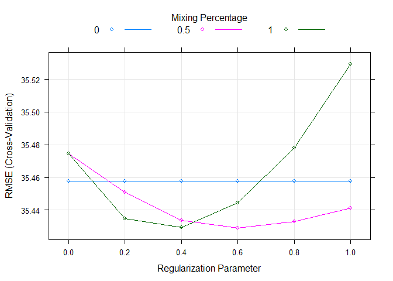

```r
plot(lassofit4)
```

```r
lassofit4$bestTune
```

```
##    alpha lambda
## 10   0.5    0.6
```

# 5 Shrinkage approaches for binary outcome

## 5.1 Optimize $\alpha$ and $\lambda$

```r
formula.bin
```

```
## cholesterol.bin ~ gender + age + born + race + education + married +
##     income + diastolicBP + systolicBP + bmi + triglycerides +
##     uric.acid + protein + bilirubin + phosphorus + sodium + potassium +
##     globulin + calcium + physical.work + physical.recreational +
##     diabetes
```

```r
TuneGrid <- expand.grid(alpha = seq(0,1,.5),
                        lambda = seq(0,.5,by = 0.1))
ctrl<-trainControl(method = "cv",
                   number = 5,
                   summaryFunction = twoClassSummary,
                   classProbs = TRUE)

lassofit5 <- train(formula.bin, method = "glmnet",
                   data = analytic3,
                   trControl = ctrl,
                   tuneGrid = TuneGrid,
                   family="binomial",
                   metric = "ROC")
lassofit5
```

```
## glmnet
##
## 2632 samples
##   22 predictor
##    2 classes: 'healthy', 'unhealthy'
##
## No pre-processing
## Resampling: Cross-Validated (5 fold)
## Summary of sample sizes: 2106, 2105, 2105, 2106, 2106
## Resampling results across tuning parameters:
##
##   alpha  lambda  ROC        Sens       Spec
##   0.0    0.0     0.7275666  0.8322878  0.44358624
##   0.0    0.1     0.7250874  0.8764280  0.35370699
##   0.0    0.2     0.7215323  0.9129933  0.26575985
##   0.0    0.3     0.7189296  0.9369502  0.20647984
##   0.0    0.4     0.7167302  0.9533361  0.16633402
##   0.0    0.5     0.7150881  0.9678392  0.13671451
##   0.5    0.0     0.7281856  0.8190445  0.45983595
##   0.5    0.1     0.6976563  0.9552348  0.14432900
##   0.5    0.2     0.6781456  0.9981092  0.02390066
##   0.5    0.3     0.5000000  1.0000000  0.00000000
##   0.5    0.4     0.5000000  1.0000000  0.00000000
##   0.5    0.5     0.5000000  1.0000000  0.00000000
##   1.0    0.0     0.7282761  0.8190445  0.46079289
##   1.0    0.1     0.6781456  0.9930619  0.05544771
##   1.0    0.2     0.5000000  1.0000000  0.00000000
##   1.0    0.3     0.5000000  1.0000000  0.00000000
##   1.0    0.4     0.5000000  1.0000000  0.00000000
##   1.0    0.5     0.5000000  1.0000000  0.00000000
##
## ROC was used to select the optimal model using the largest value.
## The final values used for the model were alpha = 1 and lambda = 0.
```

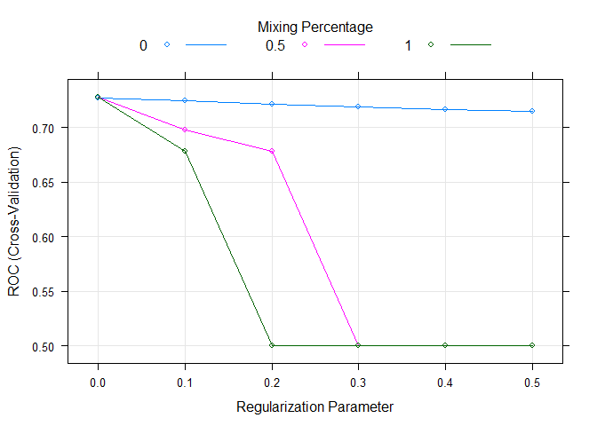

```r
plot(lassofit5)
```

```r
lassofit5$bestTune
```

```
##    alpha lambda
## 13     1      0
```

```r
predict.train(object=lassofit5,head(analytic3),type="prob")
```

```
##     healthy unhealthy
## 1 0.6776252 0.3223748
## 2 0.3207300 0.6792700
## 3 0.7070347 0.2929653
## 4 0.5981187 0.4018813
## 5 0.8587772 0.1412228
## 6 0.2398327 0.7601673
```

# 6 Decision Trees

## 6.1 Tree

```r
# maximum depth of any node of the final tree
TuneGrid <- expand.grid(maxdepth = 2)
rpartfit <- train(formula.bin,
                   method = "rpart2",
                   data = analytic3,
                   tuneGrid = TuneGrid,
                   trControl = ctrl,
                   metric = "ROC")
rpartfit
```

```
## CART
##
## 2632 samples
##   22 predictor
##    2 classes: 'healthy', 'unhealthy'
##
## No pre-processing
## Resampling: Cross-Validated (5 fold)
## Summary of sample sizes: 2106, 2106, 2105, 2105, 2106
## Resampling results:
##
##   ROC        Sens       Spec
##   0.6442535  0.8278198  0.353707
##
## Tuning parameter 'maxdepth' was held constant at a value of 2
```

```r
rpartfit$finalModel
```

```
## n= 2632
##
## node), split, n, loss, yval, (yprob)
##       * denotes terminal node
##
## 1) root 2632 1046 healthy (0.6025836 0.3974164)
##   2) triglycerides< 108.5 1114  275 healthy (0.7531418 0.2468582) *
##   3) triglycerides>=108.5 1518  747 unhealthy (0.4920949 0.5079051)
##     6) triglycerides< 240.5 1095  495 healthy (0.5479452 0.4520548) *
##     7) triglycerides>=240.5 423  147 unhealthy (0.3475177 0.6524823) *
```

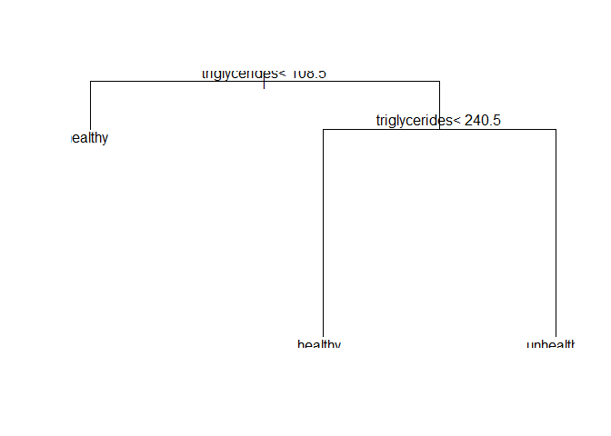

```r
plot(rpartfit$finalModel)
text(rpartfit$finalModel)
```

```r
predict.train(object=rpartfit,head(analytic3),type="prob")
```

```
##      healthy unhealthy
## 1  0.5479452 0.4520548
## 2  0.5479452 0.4520548
## 4  0.7531418 0.2468582
## 5  0.7531418 0.2468582
## 10 0.7531418 0.2468582
## 11 0.3475177 0.6524823
```

## 6.2 Optimizing depth

```r
TuneGrid <- expand.grid(maxdepth = 2:10)
ctrl<-trainControl(method = "cv",
                   number = 5,
                   summaryFunction = twoClassSummary,
                   classProbs = TRUE)
rpartfit2 <- train(formula.bin,
                   method = "rpart2",
                   data = analytic3,
                   tuneGrid = TuneGrid,
                   trControl = ctrl,
                   metric = "ROC")
rpartfit2
```

```
## CART
##
## 2632 samples
##   22 predictor
##    2 classes: 'healthy', 'unhealthy'
##
## No pre-processing
## Resampling: Cross-Validated (5 fold)
## Summary of sample sizes: 2106, 2106, 2105, 2106, 2105
## Resampling results across tuning parameters:
##
##   maxdepth  ROC        Sens       Spec
##    2        0.6467386  0.8474456  0.3507359
##    3        0.6532998  0.7382973  0.5201139
##    4        0.6531745  0.7578557  0.4923627
##    5        0.6570694  0.7849711  0.4665482
##    6        0.6570694  0.7849711  0.4665482
##    7        0.6572724  0.8038986  0.4550786
##    8        0.6572724  0.8038986  0.4550786
##    9        0.6572724  0.8038986  0.4550786
##   10        0.6572724  0.8038986  0.4550786
##
## ROC was used to select the optimal model using the largest value.
## The final value used for the model was maxdepth = 7.
```

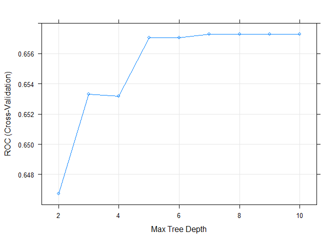

```r
plot(rpartfit2)
```

```r
rpartfit2$bestTune
```

```
##   maxdepth
## 6        7
```

```r
rpartfit2$finalModel
```

```
## n= 2632
##
## node), split, n, loss, yval, (yprob)
##       * denotes terminal node
##
##   1) root 2632 1046 healthy (0.6025836 0.3974164)
##     2) triglycerides< 108.5 1114  275 healthy (0.7531418 0.2468582) *
##     3) triglycerides>=108.5 1518  747 unhealthy (0.4920949 0.5079051)
##       6) triglycerides< 240.5 1095  495 healthy (0.5479452 0.4520548)
##        12) diastolicBP< 71 575  218 healthy (0.6208696 0.3791304)
##          24) genderMale>=0.5 279   79 healthy (0.7168459 0.2831541) *
##          25) genderMale< 0.5 296  139 healthy (0.5304054 0.4695946)
##            50) age< 46.5 139   49 healthy (0.6474820 0.3525180) *
##            51) age>=46.5 157   67 unhealthy (0.4267516 0.5732484)
##             102) diabetesYes>=0.5 40   14 healthy (0.6500000 0.3500000) *
##             103) diabetesYes< 0.5 117   41 unhealthy (0.3504274 0.6495726) *
##        13) diastolicBP>=71 520  243 unhealthy (0.4673077 0.5326923)
##          26) calcium< 9.45 302  137 healthy (0.5463576 0.4536424) *
##          27) calcium>=9.45 218   78 unhealthy (0.3577982 0.6422018) *
##       7) triglycerides>=240.5 423  147 unhealthy (0.3475177 0.6524823) *
```

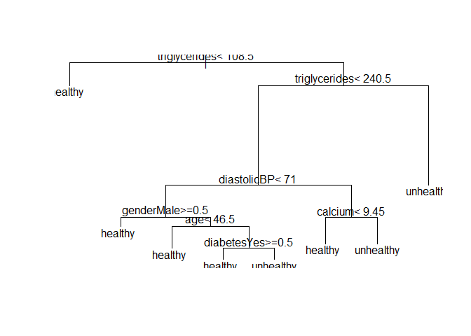

```r
plot(rpartfit2$finalModel)
text(rpartfit2$finalModel)
```

```r
predict.train(object=rpartfit2,head(analytic3),type="prob")
```

```
##      healthy unhealthy
## 1  0.7168459 0.2831541
## 2  0.3577982 0.6422018
## 4  0.7531418 0.2468582
## 5  0.7531418 0.2468582
## 10 0.7531418 0.2468582
## 11 0.3475177 0.6524823
```

## 6.3 Boosting

```r
require(gbm)
TuneGrid <- expand.grid(interaction.depth = seq(1, 3, by = 1),
                       n.trees = seq(100, 900, by = 300),
                       shrinkage = c(0.01, 0.1),
                       n.minobsinnode = 10)
ctrl<-trainControl(method = "cv",
                   number = 5,
                   summaryFunction = twoClassSummary,
                   classProbs = TRUE)
gbmTune <- train(formula.bin,
                 method = "gbm",
                 data = analytic3,
                 tuneGrid = TuneGrid,
                 trControl = ctrl,
                 metric = "ROC",
                 verbose = FALSE)
```

```r
gbmTune
```

```
## Stochastic Gradient Boosting
##
## 2632 samples
##   22 predictor
##    2 classes: 'healthy', 'unhealthy'
##
## No pre-processing
## Resampling: Cross-Validated (5 fold)
## Summary of sample sizes: 2106, 2106, 2104, 2106, 2106
## Resampling results across tuning parameters:
##
##   shrinkage  interaction.depth  n.trees  ROC        Sens       Spec
##   0.01       1                  100      0.6881146  0.9363193  0.1816086
##   0.01       1                  400      0.7150174  0.8379521  0.3900342
##   0.01       1                  700      0.7263896  0.8291431  0.4320848
##   0.01       2                  100      0.7054998  0.9293752  0.2208202
##   0.01       2                  400      0.7310294  0.8316668  0.4397220
##   0.01       2                  700      0.7374777  0.8165327  0.4837229
##   0.01       3                  100      0.7195914  0.9173958  0.2714878
##   0.01       3                  400      0.7382590  0.8215761  0.4741353
##   0.01       3                  700      0.7422758  0.8108466  0.5076282
##   0.10       1                  100      0.7289018  0.8127453  0.4445477
##   0.10       1                  400      0.7274720  0.7925699  0.5124129
##   0.10       1                  700      0.7252891  0.7944428  0.5143222
##   0.10       2                  100      0.7388366  0.8114914  0.4884803
##   0.10       2                  400      0.7270192  0.7856298  0.5171748
##   0.10       2                  700      0.7169114  0.7761582  0.5219777
##   0.10       3                  100      0.7335974  0.7938297  0.5114286
##   0.10       3                  400      0.7184184  0.7704899  0.5324903
##   0.10       3                  700      0.7090259  0.7604151  0.5219503
##
## Tuning parameter 'n.minobsinnode' was held constant at a value of 10
## ROC was used to select the optimal model using the largest value.
## The final values used for the model were n.trees = 700,
##  interaction.depth = 3, shrinkage = 0.01 and n.minobsinnode = 10.
```

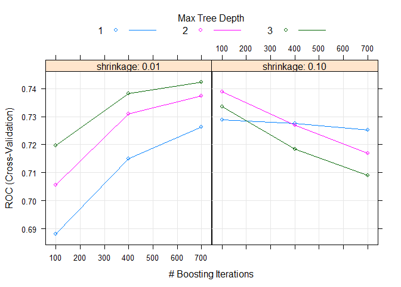

```r
plot(gbmTune)
```

```r
gbmImp <- varImp(gbmTune, scale = FALSE)
gbmImp
```

```
## gbm variable importance
##
##   only 20 most important variables shown (out of 28)
##
##                           Overall
## triglycerides             1979.29
## age                       1070.19
## diabetesYes                359.66
## calcium                    302.67
## diastolicBP                300.86
## genderMale                 260.18
## bmi                        237.32
## protein                    205.19
## potassium                  174.53
## uric.acid                  159.13
## sodium                     148.06
## phosphorus                 131.74
## bilirubin                  129.72
## systolicBP                 105.52
## globulin                    89.07
## bornOthers                  27.91
## raceHispanic                16.96
## marriedPreviously.married   13.30
## educationSchool             12.89
## marriedNever.married        12.24
```

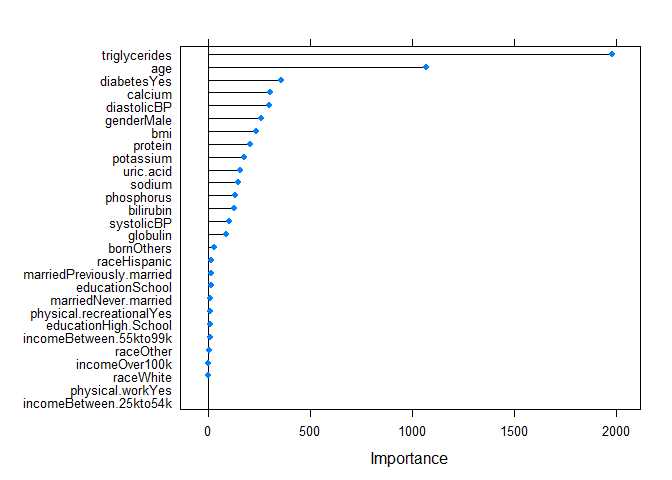

```r
plot(gbmImp)
```

```r
predict.train(object=gbmTune,head(analytic3),type="prob")
```

```
##     healthy unhealthy
## 1 0.6908760 0.3091240
## 2 0.3237730 0.6762270
## 3 0.6506950 0.3493050
## 4 0.7209053 0.2790947
## 5 0.8776949 0.1223051
## 6 0.3387282 0.6612718
```

## 6.4 Random forest

```r
require(gbm)
TuneGrid <- expand.grid(mtry = c(1, 5,20))
ctrl<-trainControl(method = "cv",
                   number = 5,
                   summaryFunction = twoClassSummary,
                   classProbs = TRUE)
rfTune <- train(formula.bin,
                 method = "rf",
                 data = analytic3,
                 tuneGrid = TuneGrid,
                 trControl = ctrl,
                 metric = "ROC",
                 verbose = FALSE)
```

```r
rfTune
```

```
## Random Forest
##
## 2632 samples
##   22 predictor
##    2 classes: 'healthy', 'unhealthy'
##
## No pre-processing
## Resampling: Cross-Validated (5 fold)
## Summary of sample sizes: 2106, 2106, 2105, 2105, 2106
## Resampling results across tuning parameters:
##
##   mtry  ROC        Sens       Spec
##    1    0.7052449  0.9993691  0.01818182
##    5    0.7238719  0.8089578  0.45886990
##   20    0.7143467  0.7805746  0.48661198
##
## ROC was used to select the optimal model using the largest value.
## The final value used for the model was mtry = 5.
```

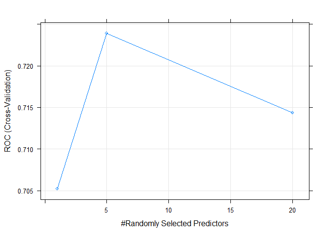

```r
plot(rfTune)
```

```r
rfImp <- varImp(rfTune, scale = FALSE)
rfImp
```

```
## rf variable importance
##
##   only 20 most important variables shown (out of 28)
##
##                          Overall
## triglycerides             169.49
## age                       120.09
## bmi                        92.23
## potassium                  84.16
## uric.acid                  80.10
## diastolicBP                76.20
## systolicBP                 75.24
## phosphorus                 69.78
## protein                    68.54
## calcium                    67.36
## globulin                   61.40
## bilirubin                  56.34
## sodium                     54.93
## genderMale                 18.17
## diabetesYes                17.89
## educationHigh.School       13.87
## marriedNever.married       12.78
## physical.recreationalYes   12.42
## bornOthers                 12.24
## raceHispanic               12.18
```

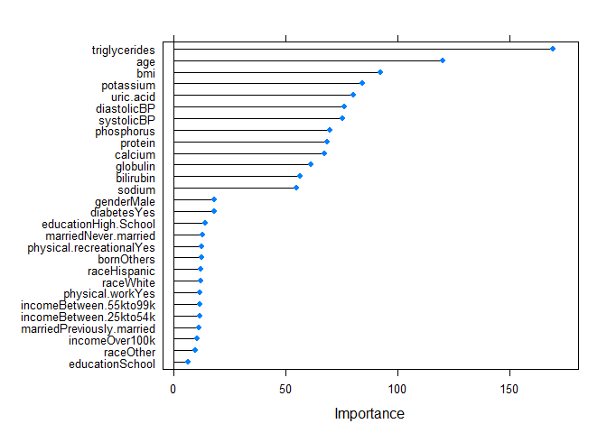

```r
plot(rfImp)
```

```r
predict.train(object=rfTune,head(analytic3),type="prob")
```

```
##    healthy unhealthy
## 1    0.892     0.108
## 2    0.126     0.874
## 4    0.878     0.122
## 5    0.288     0.712
## 10   0.904     0.096
## 11   0.758     0.242
```

# 7 Propensity score (PS) modelling

## 7.1 Super Learner (SL) to estimate PS

```r
require(SuperLearner)
listWrappers(what = 'SL')
```

```
## All prediction algorithm wrappers in SuperLearner:
```

```
##  [1] "SL.bartMachine"      "SL.bayesglm"         "SL.biglasso"
##  [4] "SL.caret"            "SL.caret.rpart"      "SL.cforest"
##  [7] "SL.earth"            "SL.extraTrees"       "SL.gam"
## [10] "SL.gbm"              "SL.glm"              "SL.glm.interaction"
## [13] "SL.glmnet"           "SL.ipredbagg"        "SL.kernelKnn"
## [16] "SL.knn"              "SL.ksvm"             "SL.lda"
## [19] "SL.leekasso"         "SL.lm"               "SL.loess"
## [22] "SL.logreg"           "SL.mean"             "SL.nnet"
## [25] "SL.nnls"             "SL.polymars"         "SL.qda"
## [28] "SL.randomForest"     "SL.ranger"           "SL.ridge"
## [31] "SL.rpart"            "SL.rpartPrune"       "SL.speedglm"
## [34] "SL.speedlm"          "SL.step"             "SL.step.forward"
## [37] "SL.step.interaction" "SL.stepAIC"          "SL.svm"
## [40] "SL.template"         "SL.xgboost"
```

```r
SL.library <- c("SL.glm", "SL.glmnet", "SL.rpart")
Y <- analytic3$cholesterol.bin.num
A <- as.numeric(I(analytic3$diabetes == "Yes"))
X <- analytic3[c("gender", "age", "born", "race", "education", "married",
                 "income", "diastolicBP", "systolicBP", "bmi",
                 "triglycerides", "uric.acid", "protein", "bilirubin",
                 "phosphorus", "sodium", "potassium", "globulin",
                 "calcium", "physical.work","physical.recreational")
]
cv.fit <- CV.SuperLearner(Y = A, X = X, family="binomial",
                          SL.library=SL.library, verbose=TRUE,
                          V=5, method = "method.NNLS")
```

[output not shown]

[output not shown]

[output not shown]

[output not shown]

[output not shown]

[output not shown]

[output not shown]

[output not shown]

[output not shown]

[output not shown]

[output not shown]

[output not shown]

[output not shown]

[output not shown]

[output not shown]

[output not shown]

[output not shown]

[output not shown]

[output not shown]

[output not shown]

[output not shown]

[output not shown]

[output not shown]

[output not shown]

[output not shown]

[output not shown]

[output not shown]

[output not shown]

[output not shown]

[output not shown]

[output not shown]

[output not shown]

[output not shown]

[output not shown]

[output not shown]

[output not shown]

[output not shown]

[output not shown]

[output not shown]

[output not shown]

[output not shown]

[output not shown]

[output not shown]

[output not shown]

[output not shown]

[output not shown]

[output not shown]

[output not shown]

[output not shown]

[output not shown]

[output not shown]

[output not shown]

[output not shown]

[output not shown]

[output not shown]

[output not shown]

[output not shown]

[output not shown]

[output not shown]

[output not shown]

[output not shown]

[output not shown]

[output not shown]

[output not shown]

[output not shown]

[output not shown]

[output not shown]

[output not shown]

[output not shown]

[output not shown]

[output not shown]

[output not shown]

[output not shown]

[output not shown]

[output not shown]

[output not shown]

[output not shown]

[output not shown]

[output not shown]

[output not shown]

[output not shown]

[output not shown]

[output not shown]

[output not shown]

[output not shown]

[output not shown]

[output not shown]

[output not shown]

[output not shown]

[output not shown]

[output not shown]

[output not shown]

[output not shown]

[output not shown]

[output not shown]

[output not shown]

[output not shown]

[output not shown]

[output not shown]

[output not shown]

[output not shown]

[output not shown]

[output not shown]

[output not shown]

[output not shown]

[output not shown]

[output not shown]

[output not shown]

[output not shown]

[output not shown]

[output not shown]

[output not shown]

[output not shown]

[output not shown]

[output not shown]

[output not shown]

[output not shown]

[output not shown]

[output not shown]

[output not shown]

[output not shown]

[output not shown]

[output not shown]

[output not shown]

[output not shown]

[output not shown]

[output not shown]

[output not shown]

[output not shown]

[output not shown]

[output not shown]

[output not shown]

[output not shown]

[output not shown]

[output not shown]

[output not shown]

[output not shown]

[output not shown]

[output not shown]

[output not shown]

[output not shown]

[output not shown]

[output not shown]

[output not shown]

[output not shown]

[output not shown]

[output not shown]

[output not shown]

[output not shown]

[output not shown]

[output not shown]

[output not shown]

[output not shown]

[output not shown]

[output not shown]

[output not shown]

[output not shown]

[output not shown]

[output not shown]

[output not shown]

[output not shown]

[output not shown]

[output not shown]

[output not shown]

[output not shown]

[output not shown]

[output not shown]

[output not shown]

[output not shown]

[output not shown]

[output not shown]

[output not shown]

[output not shown]

[output not shown]

[output not shown]

[output not shown]

[output not shown]

[output not shown]

[output not shown]

[output not shown]

[output not shown]

[output not shown]

[output not shown]

[output not shown]

[output not shown]

[output not shown]

[output not shown]

[output not shown]

[output not shown]

[output not shown]

[output not shown]

[output not shown]

[output not shown]

[output not shown]

[output not shown]

[output not shown]

[output not shown]

[output not shown]

[output not shown]

[output not shown]

[output not shown]

[output not shown]

[output not shown]

[output not shown]

[output not shown]

[output not shown]

[output not shown]

[output not shown]

[output not shown]

[output not shown]

[output not shown]

[output not shown]

[output not shown]

[output not shown]

[output not shown]

[output not shown]

[output not shown]

[output not shown]

[output not shown]

[output not shown]

## 7.2 Extract all PS

```r
predictions <- cbind(cv.fit$SL.predict,cv.fit$library.predict)
head(predictions)
```

```
##                 SL.glm_All SL.glmnet_All SL.rpart_All
## [1,] 0.37817254 0.43748893    0.36621128   0.18709677
## [2,] 0.14910672 0.15844414    0.14926835   0.13098237
## [3,] 0.14304114 0.13437659    0.14726683   0.15116279
## [4,] 0.06150200 0.04875785    0.06796537   0.08185053
## [5,] 0.03932878 0.03189434    0.03915543   0.08185053
## [6,] 0.04823257 0.04771225    0.04812157   0.06067961
```

## 7.3 Match with PS from SL

```r
ps<-predictions[,1]
summary(ps)
```

```
##     Min.  1st Qu.   Median     Mean  3rd Qu.     Max.
## 0.001694 0.036702 0.087552 0.140897 0.197664 0.871544
```

```r
require(Matching)
match<-Match(Y=Y, Tr=A, X=ps, caliper=0.2,
               M=1,estimand="ATT",ties=TRUE,
               version="standard",replace=FALSE)
summary(match)
```

```
##
## Estimate...  0.17416
## SE.........  0.035885
## T-stat.....  4.8532
## p.val......  1.2148e-06
##
## Original number of observations..............  2632
## Original number of treated obs...............  370
## Matched number of observations...............  356
## Matched number of observations  (unweighted).  356
##
## Caliper (SDs)........................................   0.2
## Number of obs dropped by 'exact' or 'caliper'  14
```

```r
matched <- rbind(analytic3[match$index.treated,],
                 analytic3[match$index.control,])
```

## 7.4 Check PS balance for PS from SL

```r
require(tableone)
varb <- c("gender", "age", "born", "race", "education", "married",
                 "income", "diastolicBP", "systolicBP", "bmi",
                 "triglycerides", "uric.acid", "protein", "bilirubin",
                 "phosphorus", "sodium", "potassium", "globulin",
                 "calcium", "physical.work","physical.recreational")
tab0 <- CreateTableOne(data=analytic3, strata= "diabetes",
                       var = varb)
sdiff.before <- ExtractSmd(tab0)
tab1 <- CreateTableOne(data=matched, strata= "diabetes",
                       var = varb)
sdiff.after<- ExtractSmd(tab1)
cbind(sdiff.before, sdiff.after)
```

```
##                           1 vs 2      1 vs 2
## gender                0.15329264 0.085090720
## age                   0.89010829 0.064639353
## born                  0.03353879 0.018779550
## race                  0.25178993 0.090096328
## education             0.17991579 0.080627901
## married               0.32319385 0.071151174
## income                0.27593185 0.051153857
## diastolicBP           0.02385494 0.014314717
## systolicBP            0.45741286 0.093838741
## bmi                   0.48590602 0.080361486
## triglycerides         0.27351162 0.019694429
## uric.acid             0.04823749 0.025553758
## protein               0.02756935 0.001879957
## bilirubin             0.08455517 0.037686946
## phosphorus            0.01670245 0.023790255
## sodium                0.22936462 0.052653544
## potassium             0.32520450 0.091465321
## globulin              0.32094881 0.012343946
## calcium               0.02743281 0.038569417
## physical.work         0.26929529 0.007633032
## physical.recreational 0.41403287 0.084036826
```

## 7.5 Compare SMDs

```r
SL.library
```

```
## [1] "SL.glm"    "SL.glmnet" "SL.rpart"
```

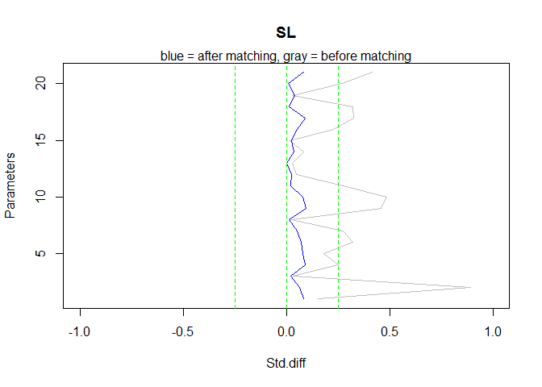

```r
SL.lib <- c("SL", SL.library)
plot(sdiff.before,1:length(varb),type="l", col = "gray",
       xlab="Std.diff", main = SL.lib[1],
       xlim=c(-1,1), ylab = "Parameters")
lines(sdiff.after,1:length(varb),type="l", col = "blue")
abline(v=0, col = "green", lty = 2)
abline(v=.25, col = "green", lty = 2)
abline(v=-.25, col = "green", lty = 2)
mtext("blue = after matching, gray = before matching")
```

## 7.6 PS from each candidate learners

```r
require(tableone)
SL.library
```

```
## [1] "SL.glm"    "SL.glmnet" "SL.rpart"
```

```
## Result from SL.glm
```

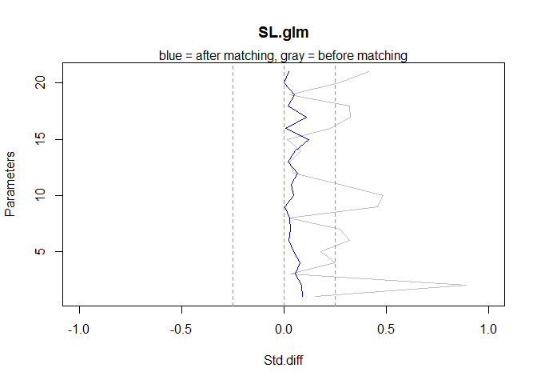

```
## Result from SL.glmnet
```

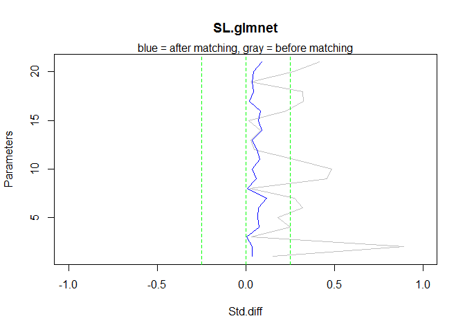

```
## Result from SL.rpart
```

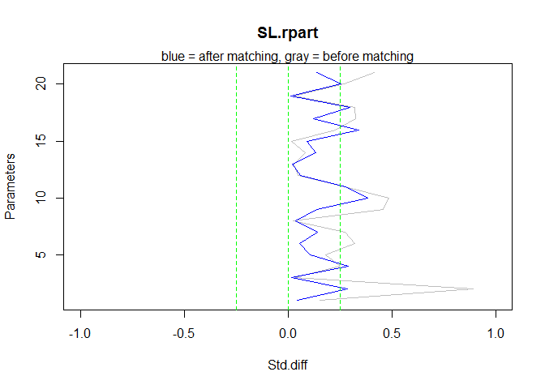

```r
SL.lib <- c("SL", SL.library)
for (k in 2:length(SL.lib)){
  cat("Result from", SL.lib[k], "\n")
  ps<-predictions[,k]
  summary(ps)
  require(Matching)
  match<-Match(Y=Y, Tr=A, X=ps, caliper=0.2,
               M=1,estimand="ATT",ties=TRUE,
               version="standard",replace=FALSE)
  matched <- rbind(analytic3[match$index.treated,],
                 analytic3[match$index.control,])
  tab0 <- CreateTableOne(data=analytic3, strata= "diabetes",
                       var = varb)
  sdiff.before <- ExtractSmd(tab0)
  tab1 <- CreateTableOne(data=matched, strata= "diabetes",
                       var = varb)
  sdiff.after<- ExtractSmd(tab1)
  sdiff.after
  plot(sdiff.before,1:length(varb),type="l", col = "gray",
       xlab="Std.diff", main = SL.lib[k],
       xlim=c(-1,1), ylab = "Parameters")
  lines(sdiff.after,1:length(varb),type="l", col = "blue")
  abline(v=0, col = "green", lty = 2)
  abline(v=.25, col = "green", lty = 2)
  abline(v=-.25, col = "green", lty = 2)
  mtext("blue = after matching, gray = before matching")
}
```

# Reference

Kuhn, Max, and Kjell Johnson. 2013. *Applied Predictive Modeling*. Vol. 26. Springer.